# STEM vs Arts Homework T Test

```r
library(tidyverse)
library(DT)
library(pander)
library(readr)
library(car)

HSS <- read_csv("../../Data/HighSchoolSeniors.csv")
#Remember: select "Session, Set Working Directory, To Source File Location", and then play this R-chunk into your console to read the HSS data into R.

HSS2 <- HSS %>%
  select(Favorite_School_Subject, Doing_Homework_Hours) %>%
  mutate(
    Genre = case_when(is.na(Favorite_School_Subject) ~ "missing",
                        Favorite_School_Subject=="Mathematics and statistics" |
                        Favorite_School_Subject=="Science" |
                        Favorite_School_Subject=="Computers and technology" ~ "STEM",
                      Favorite_School_Subject=="Art" |
                        Favorite_School_Subject=="English" |
                        Favorite_School_Subject=="Languages" |
                        Favorite_School_Subject=="Social studies" |
                        Favorite_School_Subject=="Music" |
                        Favorite_School_Subject=="History" |
                        Favorite_School_Subject=="Geography" ~ "Arts",
                      Favorite_School_Subject=="Other" |
                        Favorite_School_Subject=="Physical education" ~ "Other"))

HSS3 <- HSS2 %>%
    filter(Doing_Homework_Hours < 50 & Genre != "missing" & Genre != "Other")

HSSSTEM <- HSS3 %>%
  filter(Genre == "STEM")

HSSArt <- HSS3 %>%
  filter(Genre == "Arts")
```

## Question

I chose to examine the differences in reported amount of homework per week between students whose favorite subject is a STEM subject versus an Art. My test question is: Is there a difference in the amount of homework completed by students who favor STEM subjects and students who favor the Arts?

I modified the orignal “HSS” dataset to be as accurate as possible, removing data that seemed to be inaccurate. This was done by removing all individuals who reported 50 hours or more of homework done each week, because I deemed that as a good threshold for an accurate representation of the true amount of hours spent per week, given that these are all estimates. The remaining data was then classified into one of 3 categories, based on what the reported favorite subject in school was: STEM, Arts, or Other. “STEM” includes Mathematics and Statistics, Science, and Computers and Technology. The “Arts” category contains Art, English, Languages, Social Studies, Music, History and Geography. “Other” only contains those who listed Physical Education or Other as their favorite subject and was not included in the test. For the intent of this test, it is generally assumed that students who favor one subject or the other will be enrolled in more courses of the favored subject.

## Analysis

I ran a two Independent Samples T-test comparing the difference in means of hours of homework reported each week between students who are in the STEM or Arts categories. The hypotheses corresponding to this test are as follows:

$$H_O: \mu_\text{Arts} - \mu_\text{STEM} = 0$$
$$H_A: \mu_\text{Arts} - \mu_\text{STEM} \neq 0$$
The significance level for this study will be set at:

$$\alpha = 0.05$$

Below are Q-Q Plots for each of the two groups. Though they are both shown to be right-skewed, with sample sizes of 172 and 182 respectively, according to the Central Limit Theorem, the distribution of sample means of all possible samples will be normally distributed, thus making the results trustworthy.

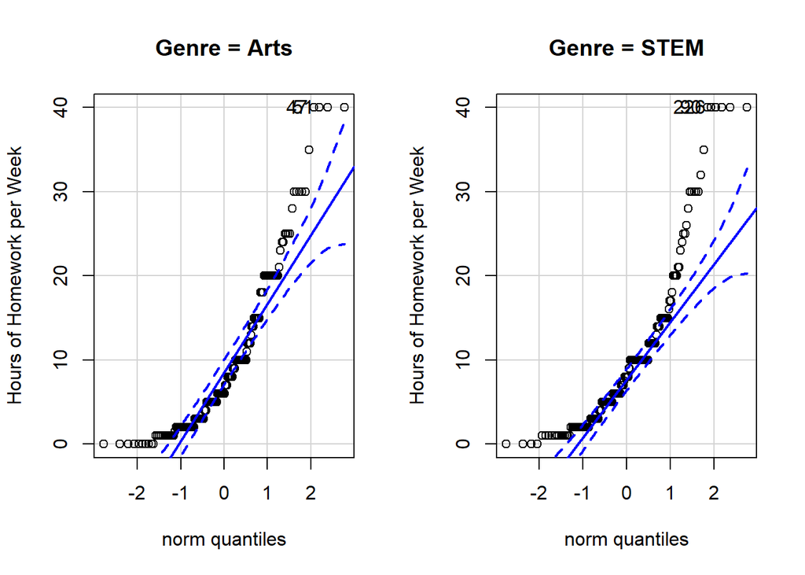

```r
qqPlot(Doing_Homework_Hours ~ Genre, HSS3, ylab = "Hours of Homework per Week")
```

These Boxplots show that the medians of each of the groups lie around 6-8, with the STEM group having a slightly higher mean, as shown in the T Test.

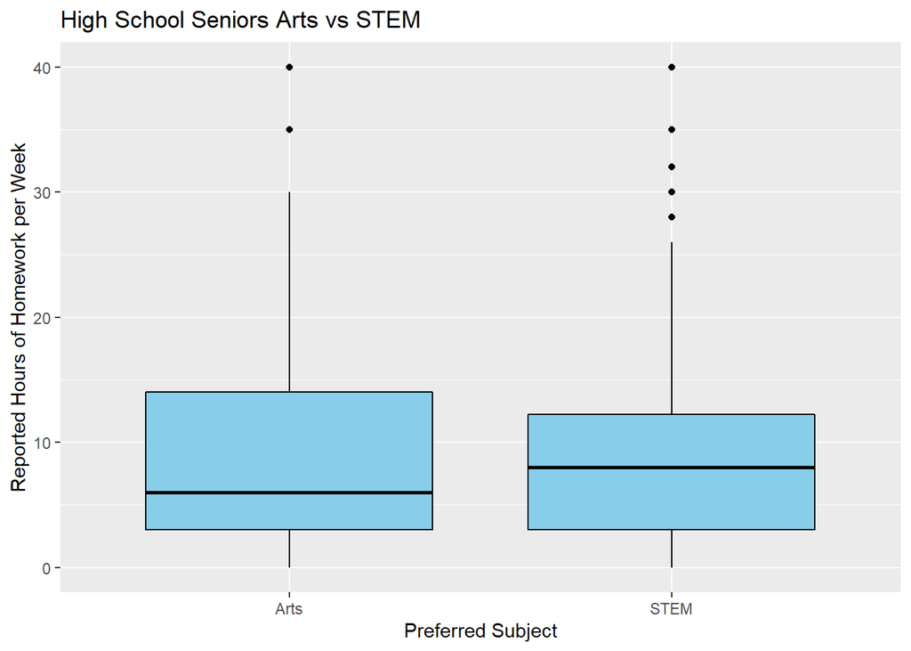

```r
ggplot(HSS3, aes(x=factor(Genre), y=Doing_Homework_Hours))+
    geom_boxplot(fill="skyblue", color="black")+
labs(title="High School Seniors Arts vs STEM", x="Preferred Subject", y="Reported Hours of Homework per Week")
```

Below are the results from the two independent samples t test with a chosen confidence level of 0.95:

```r
t.test(Doing_Homework_Hours ~ Genre, data=HSS3) %>% pander(split.table=Inf)
```

Welch Two Sample t-test: `Doing_Homework_Hours` by `Genre`

| Test statistic | df | P value | Alternative hypothesis | mean in group Arts | mean in group STEM |
| --- | --- | --- | --- | --- | --- |
| -0.6307 | 349.6 | 0.5287 | two.sided | 9.607 | 10.23 |

## Conclusion

Given our p-value of 0.5287 and a significance level of 0.05, we have insufficient evidence to reject the null hypothesis. This may be interpreted to mean that there is not a significant difference between the amount of time spent on homework between students favoring STEM and students favoring the Arts. The results of the test support what can be seen be looking at the boxplot and the means of each group, both being quite similar. The mean of Arts is 9.607 and the mean of STEM is 10.23, which are relatively close to each other. We also see that the medians of the two groups are relatively close to each other based on the boxplots, which is then again supported by our p-value.

An aspect of this test that could be strenghtened through other studies and data analysis is that of the relation between favoring a certain subject in school and the amount of time you take to complete that subject’s coursework. For example, it may be commonly accepted that if an individual enjoys a certain subject, that individual will perform more well in that subject. A similar but almost opposite correlation could be observed, in that often times an individual enjoys a certain subject completely due to the fact that it comes easy to him/her. Another bias could be observed with relation to this when it is considered that some students do not complete all of their coursework, and are likely to only complete what they enjoy, or possibly they only complete the homework they do not particularly enjoy, because they perform more well in the subject they like (as previously discussed) and thus do not need to spend the amount of time studying that material as may be required to do well in the subject they do not enjoy. Also considering the fact that each of these individuals is a High School Senior, it is possible that the students would try to take courses they enjoy more sooner rather than later, so it may be that a significant proportion of one of the two observed groups is not even taking any courses in his/her favored subject.

Based on a combination of these unknown factors and the results of my test, it is safe to conclude that further investigation of this topic is necessary to be able to state a claim about the difference in time of homework done by students who favor STEM subjects and students who favor the Arts.